# LA-EDA

Jatin-Dheeraj

2023-05-14

## we using readr package to read a CSV file called “housing.csv” from your local file system and then viewing the data using the View() function.

```r
library(readr)
housing <- read_csv("C:/Users/HP/Downloads/archive (2)/housing.csv")
View(housing)
```

## The str() function in R provides a concise summary of the structure of a given object.

```r
str(housing)
```

```
## spc_tbl_ [20,640 × 10] (S3: spec_tbl_df/tbl_df/tbl/data.frame)
##  $ longitude         : num [1:20640] -122 -122 -122 -122 -122 ...
##  $ latitude          : num [1:20640] 37.9 37.9 37.9 37.9 37.9 ...
##  $ housing_median_age: num [1:20640] 41 21 52 52 52 52 52 52 42 52 ...
##  $ total_rooms       : num [1:20640] 880 7099 1467 1274 1627 ...
##  $ total_bedrooms    : num [1:20640] 129 1106 190 235 280 ...
##  $ population        : num [1:20640] 322 2401 496 558 565 ...
##  $ households        : num [1:20640] 126 1138 177 219 259 ...
##  $ median_income     : num [1:20640] 8.33 8.3 7.26 5.64 3.85 ...
##  $ median_house_value: num [1:20640] 452600 358500 352100 341300 342200 ...
##  $ ocean_proximity   : chr [1:20640] "NEAR BAY" "NEAR BAY" "NEAR BAY" "NEAR BAY" ...
##  - attr(*, "spec")=
##   .. cols(
##   ..   longitude = col_double(),
##   ..   latitude = col_double(),
##   ..   housing_median_age = col_double(),
##   ..   total_rooms = col_double(),
##   ..   total_bedrooms = col_double(),
##   ..   population = col_double(),
##   ..   households = col_double(),
##   ..   median_income = col_double(),
##   ..   median_house_value = col_double(),
##   ..   ocean_proximity = col_character()
##   .. )
##  - attr(*, "problems")=<externalptr>
```

## table(housing$households) in R creates a frequency table that shows the number of occurrences of each unique value in the households column of the housing data frame.

```r
options(max.print = 30)
table(housing $ households)
```

```
##
##  1  2  3  4  5  6  7  8  9 10 11 12 13 14 15 16 17 18 19 20 21 22 23 24 25 26
##  1  3  4  4  7  5 10  8  9  7  4  2 10 12  7 10  6  4  6  8 12  9  7  5  8  6
## 27 28 29 30
## 11  3  9  5
##  [ reached getOption("max.print") -- omitted 1785 entries ]
```

## By changing the options(“max.print”) value, you can set the default number of rows to display.

```r
options(max.print = 30)
```

## class(housing)” will return the class of the object “housing”.

```r
class(housing)
```

```
## [1] "spec_tbl_df" "tbl_df"      "tbl"         "data.frame"
```

## head(housing)” will display the first few rows of the “housing” dataset or data frame, allowing the user to quickly preview the structure and contents of the data

```r
head(housing)
```

| longitude | latitude | housing_median_age | total_rooms | total_bedrooms | population | households | median_income | median_house_value | ocean_proximity |
| --- | --- | --- | --- | --- | --- | --- | --- | --- | --- |
| -122.23 | 37.88 | 41 | 880 | 129 | 322 | 126 | 8.3252 | 452600 | NEAR BAY |
| -122.22 | 37.86 | 21 | 7099 | 1106 | 2401 | 1138 | 8.3014 | 358500 | NEAR BAY |
| -122.24 | 37.85 | 52 | 1467 | 190 | 496 | 177 | 7.2574 | 352100 | NEAR BAY |
| -122.25 | 37.85 | 52 | 1274 | 235 | 558 | 219 | 5.6431 | 341300 | NEAR BAY |
| -122.25 | 37.85 | 52 | 1627 | 280 | 565 | 259 | 3.8462 | 342200 | NEAR BAY |
| -122.25 | 37.85 | 52 | 919 | 213 | 413 | 193 | 4.0368 | 269700 | NEAR BAY |

## summary(): Provides a summary of a data frame

```r
summary(housing)
```

```
##    longitude         latitude     housing_median_age  total_rooms
##  Min.   :-124.3   Min.   :32.54   Min.   : 1.00      Min.   :    2
##  1st Qu.:-121.8   1st Qu.:33.93   1st Qu.:18.00      1st Qu.: 1448
##  Median :-118.5   Median :34.26   Median :29.00      Median : 2127
##  total_bedrooms     population      households     median_income
##  Min.   :   1.0   Min.   :    3   Min.   :   1.0   Min.   : 0.4999
##  1st Qu.: 296.0   1st Qu.:  787   1st Qu.: 280.0   1st Qu.: 2.5634
##  Median : 435.0   Median : 1166   Median : 409.0   Median : 3.5348
##  median_house_value ocean_proximity
##  Min.   : 14999     Length:20640
##  1st Qu.:119600     Class :character
##  Median :179700     Mode  :character
##  [ reached getOption("max.print") -- omitted 4 rows ]
```

## dim(): Shows the dimensions of a data frame

```r
  dim(housing)
```

```
## [1] 20640    10
```

## nrow(): Shows the number of rows in a data frame

```r
  nrow(housing)
```

```
## [1] 20640
```

## ncol(): Shows the number of columns in a data frame

```r
  ncol(housing)
```

```
## [1] 10
```

## names(): Shows the column names of a data frame

```r
names(housing)
```

```
##  [1] "longitude"          "latitude"           "housing_median_age"
##  [4] "total_rooms"        "total_bedrooms"     "population"
##  [7] "households"         "median_income"      "median_house_value"
## [10] "ocean_proximity"
```

## tail(): Shows the last few rows of a data frame

```r
  tail(housing)
```

| longitude | latitude | housing_median_age | total_rooms | total_bedrooms | population | households | median_income | median_house_value | ocean_proximity |
| --- | --- | --- | --- | --- | --- | --- | --- | --- | --- |
| -121.56 | 39.27 | 28 | 2332 | 395 | 1041 | 344 | 3.7125 | 116800 | INLAND |
| -121.09 | 39.48 | 25 | 1665 | 374 | 845 | 330 | 1.5603 | 78100 | INLAND |
| -121.21 | 39.49 | 18 | 697 | 150 | 356 | 114 | 2.5568 | 77100 | INLAND |
| -121.22 | 39.43 | 17 | 2254 | 485 | 1007 | 433 | 1.7000 | 92300 | INLAND |
| -121.32 | 39.43 | 18 | 1860 | 409 | 741 | 349 | 1.8672 | 84700 | INLAND |
| -121.24 | 39.37 | 16 | 2785 | 616 | 1387 | 530 | 2.3886 | 89400 | INLAND |

## subset(): Extracts a subset of a data frame based on a condition

```r
  subset(housing)
```

| longitude | latitude | housing_median_age | total_rooms | total_bedrooms | population | households | median_income | median_house_value | ocean_proximity |
| --- | --- | --- | --- | --- | --- | --- | --- | --- | --- |
| -122.23 | 37.88 | 41 | 880 | 129 | 322 | 126 | 8.3252 | 452600 | NEAR BAY |
| -122.22 | 37.86 | 21 | 7099 | 1106 | 2401 | 1138 | 8.3014 | 358500 | NEAR BAY |
| -122.24 | 37.85 | 52 | 1467 | 190 | 496 | 177 | 7.2574 | 352100 | NEAR BAY |
| -122.25 | 37.85 | 52 | 1274 | 235 | 558 | 219 | 5.6431 | 341300 | NEAR BAY |
| -122.25 | 37.85 | 52 | 1627 | 280 | 565 | 259 | 3.8462 | 342200 | NEAR BAY |
| -122.25 | 37.85 | 52 | 919 | 213 | 413 | 193 | 4.0368 | 269700 | NEAR BAY |
| -122.25 | 37.84 | 52 | 2535 | 489 | 1094 | 514 | 3.6591 | 299200 | NEAR BAY |
| -122.25 | 37.84 | 52 | 3104 | 687 | 1157 | 647 | 3.1200 | 241400 | NEAR BAY |
| -122.26 | 37.84 | 42 | 2555 | 665 | 1206 | 595 | 2.0804 | 226700 | NEAR BAY |
| -122.25 | 37.84 | 52 | 3549 | 707 | 1551 | 714 | 3.6912 | 261100 | NEAR BAY |

[output cut: 20 more lines]

## select(): Selects specific columns from a data frame

## Select columns

```r
library('dplyr')
housing %>% select(2,3)
```

| latitude | housing_median_age |
| --- | --- |
| 37.88 | 41 |
| 37.86 | 21 |
| 37.85 | 52 |
| 37.85 | 52 |
| 37.85 | 52 |
| 37.85 | 52 |
| 37.84 | 52 |
| 37.84 | 52 |
| 37.84 | 42 |
| 37.84 | 52 |

[output cut: 20 more lines]

## Select columns by list of index or position

```r
housing %>% select(c(2,3))
```

| latitude | housing_median_age |
| --- | --- |
| 37.88 | 41 |
| 37.86 | 21 |
| 37.85 | 52 |
| 37.85 | 52 |
| 37.85 | 52 |
| 37.85 | 52 |
| 37.84 | 52 |
| 37.84 | 52 |
| 37.84 | 42 |
| 37.84 | 52 |

[output cut: 20 more lines]

## Select columns by index range

```r
housing %>% select(2:3)
```

| latitude | housing_median_age |
| --- | --- |
| 37.88 | 41 |
| 37.86 | 21 |
| 37.85 | 52 |
| 37.85 | 52 |
| 37.85 | 52 |
| 37.85 | 52 |
| 37.84 | 52 |
| 37.84 | 52 |
| 37.84 | 42 |
| 37.84 | 52 |

[output cut: 20 more lines]

## Select columns by label’total_rooms’,‘housing_median_age’

```r
 housing %>% select('total_rooms','housing_median_age')
```

| total_rooms | housing_median_age |
| --- | --- |
| 880 | 41 |
| 7099 | 21 |
| 1467 | 52 |
| 1274 | 52 |
| 1627 | 52 |
| 919 | 52 |
| 2535 | 52 |
| 3104 | 52 |
| 2555 | 42 |
| 3549 | 52 |

[output cut: 20 more lines]

## Select columns except ‘total_rooms’,‘housing_median_age’

```r
housing %>% select(-c('total_rooms','housing_median_age'))
```

| longitude | latitude | total_bedrooms | population | households | median_income | median_house_value | ocean_proximity |
| --- | --- | --- | --- | --- | --- | --- | --- |
| -122.23 | 37.88 | 129 | 322 | 126 | 8.3252 | 452600 | NEAR BAY |
| -122.22 | 37.86 | 1106 | 2401 | 1138 | 8.3014 | 358500 | NEAR BAY |
| -122.24 | 37.85 | 190 | 496 | 177 | 7.2574 | 352100 | NEAR BAY |
| -122.25 | 37.85 | 235 | 558 | 219 | 5.6431 | 341300 | NEAR BAY |
| -122.25 | 37.85 | 280 | 565 | 259 | 3.8462 | 342200 | NEAR BAY |
| -122.25 | 37.85 | 213 | 413 | 193 | 4.0368 | 269700 | NEAR BAY |
| -122.25 | 37.84 | 489 | 1094 | 514 | 3.6591 | 299200 | NEAR BAY |
| -122.25 | 37.84 | 687 | 1157 | 647 | 3.1200 | 241400 | NEAR BAY |
| -122.26 | 37.84 | 665 | 1206 | 595 | 2.0804 | 226700 | NEAR BAY |
| -122.25 | 37.84 | 707 | 1551 | 714 | 3.6912 | 261100 | NEAR BAY |

[output cut: 20 more lines]

## Select columns between ‘total_rooms’,‘housing_median_age’

```r
housing %>% select('total_rooms':'housing_median_age')
```

| total_rooms | housing_median_age |
| --- | --- |
| 880 | 41 |
| 7099 | 21 |
| 1467 | 52 |
| 1274 | 52 |
| 1627 | 52 |
| 919 | 52 |
| 2535 | 52 |
| 3104 | 52 |
| 2555 | 42 |
| 3549 | 52 |

[output cut: 20 more lines]

## Select columns starts with a string

```r
housing %>% select(starts_with('l'))
```

| longitude | latitude |
| --- | --- |
| -122.23 | 37.88 |
| -122.22 | 37.86 |
| -122.24 | 37.85 |
| -122.25 | 37.85 |
| -122.25 | 37.85 |
| -122.25 | 37.85 |
| -122.25 | 37.84 |
| -122.25 | 37.84 |
| -122.26 | 37.84 |
| -122.25 | 37.84 |

[output cut: 20 more lines]

## Select columns that ends with a string

```r
housing %>% select(ends_with('e'))
```

| longitude | latitude | housing_median_age | median_income | median_house_value |
| --- | --- | --- | --- | --- |
| -122.23 | 37.88 | 41 | 8.3252 | 452600 |
| -122.22 | 37.86 | 21 | 8.3014 | 358500 |
| -122.24 | 37.85 | 52 | 7.2574 | 352100 |
| -122.25 | 37.85 | 52 | 5.6431 | 341300 |
| -122.25 | 37.85 | 52 | 3.8462 | 342200 |
| -122.25 | 37.85 | 52 | 4.0368 | 269700 |
| -122.25 | 37.84 | 52 | 3.6591 | 299200 |
| -122.25 | 37.84 | 52 | 3.1200 | 241400 |
| -122.26 | 37.84 | 42 | 2.0804 | 226700 |
| -122.25 | 37.84 | 52 | 3.6912 | 261100 |

[output cut: 20 more lines]

## Select columns that contains

```r
housing  %>% select(contains('p'))
```

| population | ocean_proximity |
| --- | --- |
| 322 | NEAR BAY |
| 2401 | NEAR BAY |
| 496 | NEAR BAY |
| 558 | NEAR BAY |
| 565 | NEAR BAY |
| 413 | NEAR BAY |
| 1094 | NEAR BAY |
| 1157 | NEAR BAY |
| 1206 | NEAR BAY |
| 1551 | NEAR BAY |

[output cut: 20 more lines]

## Select all numeric columns

```r
housing %>% select_if(is.numeric)
```

| longitude | latitude | housing_median_age | total_rooms | total_bedrooms | population | households | median_income | median_house_value |
| --- | --- | --- | --- | --- | --- | --- | --- | --- |
| -122.23 | 37.88 | 41 | 880 | 129 | 322 | 126 | 8.3252 | 452600 |
| -122.22 | 37.86 | 21 | 7099 | 1106 | 2401 | 1138 | 8.3014 | 358500 |
| -122.24 | 37.85 | 52 | 1467 | 190 | 496 | 177 | 7.2574 | 352100 |
| -122.25 | 37.85 | 52 | 1274 | 235 | 558 | 219 | 5.6431 | 341300 |
| -122.25 | 37.85 | 52 | 1627 | 280 | 565 | 259 | 3.8462 | 342200 |
| -122.25 | 37.85 | 52 | 919 | 213 | 413 | 193 | 4.0368 | 269700 |
| -122.25 | 37.84 | 52 | 2535 | 489 | 1094 | 514 | 3.6591 | 299200 |
| -122.25 | 37.84 | 52 | 3104 | 687 | 1157 | 647 | 3.1200 | 241400 |
| -122.26 | 37.84 | 42 | 2555 | 665 | 1206 | 595 | 2.0804 | 226700 |
| -122.25 | 37.84 | 52 | 3549 | 707 | 1551 | 714 | 3.6912 | 261100 |

[output cut: 20 more lines]

## subset(): Extracts a subset of a data frame based on a condition

# Syntax of subset()

subset(x, subset, select, drop = FALSE, …)

## subset by row name

```r
subset(housing, subset=rownames(housing) == '41')
```

| longitude | latitude | housing_median_age | total_rooms | total_bedrooms | population | households | median_income | median_house_value | ocean_proximity |
| --- | --- | --- | --- | --- | --- | --- | --- | --- | --- |
| -122.26 | 37.83 | 52 | 1665 | 419 | 946 | 395 | 2.0978 | 155400 | NEAR BAY |

## subset row by of row values

```r
subset(housing, rownames(housing) %in% c('41','52','42'))
```

| longitude | latitude | housing_median_age | total_rooms | total_bedrooms | population | households | median_income | median_house_value | ocean_proximity |
| --- | --- | --- | --- | --- | --- | --- | --- | --- | --- |
| -122.26 | 37.83 | 52 | 1665 | 419 | 946 | 395 | 2.0978 | 155400 | NEAR BAY |
| -122.26 | 37.83 | 51 | 936 | 311 | 517 | 249 | 1.2852 | 150000 | NEAR BAY |
| -122.27 | 37.82 | 43 | 1868 | 456 | 1061 | 407 | 1.5045 | 93800 | NEAR BAY |

## subset() by Condition or Column Value

```r
  subset(housing, latitude=='37.83')
```

| longitude | latitude | housing_median_age | total_rooms | total_bedrooms | population | households | median_income | median_house_value | ocean_proximity |
| --- | --- | --- | --- | --- | --- | --- | --- | --- | --- |
| -122.27 | 37.83 | 49 | 1655 | 366 | 754 | 329 | 1.3750 | 104900 | NEAR BAY |
| -122.27 | 37.83 | 51 | 2665 | 574 | 1258 | 536 | 2.7303 | 109700 | NEAR BAY |
| -122.27 | 37.83 | 49 | 1215 | 282 | 570 | 264 | 1.4861 | 97200 | NEAR BAY |
| -122.27 | 37.83 | 48 | 1798 | 432 | 987 | 374 | 1.0972 | 104500 | NEAR BAY |
| -122.28 | 37.83 | 52 | 1511 | 390 | 901 | 403 | 1.4103 | 103900 | NEAR BAY |
| -122.26 | 37.83 | 52 | 1470 | 330 | 689 | 309 | 3.4800 | 191400 | NEAR BAY |
| -122.26 | 37.83 | 52 | 2432 | 715 | 1377 | 696 | 2.5898 | 176000 | NEAR BAY |
| -122.26 | 37.83 | 52 | 1665 | 419 | 946 | 395 | 2.0978 | 155400 | NEAR BAY |
| -122.26 | 37.83 | 51 | 936 | 311 | 517 | 249 | 1.2852 | 150000 | NEAR BAY |
| -122.26 | 37.83 | 52 | 1443 | 311 | 660 | 292 | 3.0125 | 184400 | NEAR BAY |

[output cut: 20 more lines]

## subset by multiple conditions

```r
  subset(housing, population =='754' | total_bedrooms == '311')
```

| longitude | latitude | housing_median_age | total_rooms | total_bedrooms | population | households | median_income | median_house_value | ocean_proximity |
| --- | --- | --- | --- | --- | --- | --- | --- | --- | --- |
| -122.27 | 37.83 | 49 | 1655 | 366 | 754 | 329 | 1.3750 | 104900 | NEAR BAY |
| -122.26 | 37.83 | 51 | 936 | 311 | 517 | 249 | 1.2852 | 150000 | NEAR BAY |
| -122.26 | 37.83 | 52 | 1443 | 311 | 660 | 292 | 3.0125 | 184400 | NEAR BAY |
| -122.10 | 37.64 | 28 | 1784 | 311 | 735 | 278 | 4.6635 | 206700 | NEAR BAY |
| -121.93 | 37.49 | 5 | 1150 | 311 | 648 | 245 | 3.5714 | 300000 | <1H OCEAN |
| -119.46 | 36.60 | 18 | 1404 | 226 | 754 | 229 | 3.9844 | 118100 | INLAND |
| -124.18 | 40.79 | 40 | 1398 | 311 | 788 | 279 | 1.4668 | 64600 | NEAR OCEAN |
| -119.03 | 35.42 | 45 | 1628 | 352 | 754 | 334 | 2.5703 | 62400 | INLAND |
| -118.45 | 34.26 | 35 | 1724 | 311 | 992 | 315 | 4.8359 | 195600 | <1H OCEAN |
| -118.57 | 34.20 | 33 | 1759 | 311 | 943 | 315 | 5.2230 | 209200 | <1H OCEAN |

[output cut: 20 more lines]

## subset columns

```r
  subset(housing,housing_median_age=='51',select=c('longitude','latitude'))
```

| longitude | latitude |
| --- | --- |
| -122.27 | 37.83 |
| -122.26 | 37.83 |
| -122.23 | 37.80 |
| -122.25 | 37.79 |
| -122.22 | 37.78 |
| -122.18 | 37.77 |
| -122.14 | 37.73 |
| -121.90 | 38.03 |
| -122.13 | 38.01 |
| -119.81 | 36.73 |

[output cut: 20 more lines]

## subset columns by index

```r
  subset(housing,housing_median_age=='51',select=c(1,2,3))
```

| longitude | latitude | housing_median_age |
| --- | --- | --- |
| -122.27 | 37.83 | 51 |
| -122.26 | 37.83 | 51 |
| -122.23 | 37.80 | 51 |
| -122.25 | 37.79 | 51 |
| -122.22 | 37.78 | 51 |
| -122.18 | 37.77 | 51 |
| -122.14 | 37.73 | 51 |
| -121.90 | 38.03 | 51 |
| -122.13 | 38.01 | 51 |
| -119.81 | 36.73 | 51 |

[output cut: 20 more lines]

## filter(): Filters a data frame based on a condition

# filter() by row name

```r
library('dplyr')
filter(housing, rownames(housing) == '51')
```

| longitude | latitude | housing_median_age | total_rooms | total_bedrooms | population | households | median_income | median_house_value | ocean_proximity |
| --- | --- | --- | --- | --- | --- | --- | --- | --- | --- |
| -122.27 | 37.82 | 21 | 896 | 453 | 735 | 438 | 0.9218 | 171900 | NEAR BAY |

## filter() by column Value

```r
  filter(housing, total_rooms == '896')
```

| longitude | latitude | housing_median_age | total_rooms | total_bedrooms | population | households | median_income | median_house_value | ocean_proximity |
| --- | --- | --- | --- | --- | --- | --- | --- | --- | --- |
| -122.27 | 37.82 | 21 | 896 | 453 | 735 | 438 | 0.9218 | 171900 | NEAR BAY |
| -119.00 | 35.36 | 39 | 896 | 217 | 805 | 197 | 1.2500 | 42500 | INLAND |
| -118.29 | 33.93 | 41 | 896 | 198 | 605 | 168 | 2.2778 | 128100 | <1H OCEAN |
| -118.29 | 33.84 | 33 | 896 | 208 | 843 | 200 | 3.5000 | 183000 | <1H OCEAN |
| -120.65 | 35.28 | 32 | 896 | 240 | 548 | 231 | 2.5455 | 165900 | NEAR OCEAN |

## filter() by list of values

```r
  filter(housing, housing_median_age %in% c("21", "39", "33"))
```

| longitude | latitude | housing_median_age | total_rooms | total_bedrooms | population | households | median_income | median_house_value | ocean_proximity |
| --- | --- | --- | --- | --- | --- | --- | --- | --- | --- |
| -122.22 | 37.86 | 21 | 7099 | 1106 | 2401 | 1138 | 8.3014 | 358500 | NEAR BAY |
| -122.27 | 37.82 | 21 | 896 | 453 | 735 | 438 | 0.9218 | 171900 | NEAR BAY |
| -122.27 | 37.80 | 39 | 1715 | 623 | 1327 | 467 | 1.8477 | 179200 | NEAR BAY |
| -122.25 | 37.81 | 39 | 854 | 242 | 389 | 228 | 3.1250 | 237500 | NEAR BAY |
| -122.20 | 37.82 | 39 | 3770 | 534 | 1265 | 500 | 6.3302 | 362800 | NEAR BAY |
| -122.24 | 37.79 | 39 | 1469 | 431 | 1464 | 389 | 2.1638 | 105500 | NEAR BAY |
| -122.25 | 37.79 | 39 | 461 | 129 | 381 | 123 | 1.6000 | 112500 | NEAR BAY |
| -122.21 | 37.80 | 39 | 2003 | 500 | 1109 | 464 | 3.0682 | 156500 | NEAR BAY |
| -122.21 | 37.80 | 39 | 2018 | 447 | 1221 | 446 | 3.0757 | 151000 | NEAR BAY |
| -122.20 | 37.77 | 39 | 2689 | 597 | 1888 | 537 | 2.2562 | 94800 | NEAR BAY |

[output cut: 20 more lines]

## filter() by row number

```r
  slice(housing, 5)
```

| longitude | latitude | housing_median_age | total_rooms | total_bedrooms | population | households | median_income | median_house_value | ocean_proximity |
| --- | --- | --- | --- | --- | --- | --- | --- | --- | --- |
| -122.25 | 37.85 | 52 | 1627 | 280 | 565 | 259 | 3.8462 | 342200 | NEAR BAY |

## arrange(): Sorts a data frame by one or more columns

# Syntax of arrange()

arrange(.data, …, .by_group = FALSE)

## Using arrange in descending order

```r
  temp <- housing %>% arrange(desc(latitude))
   temp
```

| longitude | latitude | housing_median_age | total_rooms | total_bedrooms | population | households | median_income | median_house_value | ocean_proximity |
| --- | --- | --- | --- | --- | --- | --- | --- | --- | --- |
| -124.14 | 41.95 | 21 | 2696 | 578 | 1208 | 494 | 2.2750 | 122400 | NEAR OCEAN |
| -122.64 | 41.95 | 18 | 1867 | 424 | 802 | 314 | 1.8242 | 53500 | INLAND |
| -124.16 | 41.92 | 19 | 1668 | 324 | 841 | 283 | 2.1336 | 75000 | NEAR OCEAN |
| -123.83 | 41.88 | 18 | 1504 | 357 | 660 | 258 | 3.1300 | 116700 | <1H OCEAN |
| -121.93 | 41.86 | 28 | 4225 | 835 | 1908 | 686 | 1.7400 | 44000 | INLAND |
| -122.33 | 41.86 | 19 | 3599 | 695 | 1572 | 601 | 2.2340 | 58600 | INLAND |
| -123.26 | 41.86 | 25 | 2344 | 532 | 1117 | 424 | 2.7222 | 64600 | INLAND |
| -124.30 | 41.84 | 17 | 2677 | 531 | 1244 | 456 | 3.0313 | 103600 | NEAR OCEAN |
| -120.48 | 41.82 | 20 | 1367 | 284 | 429 | 181 | 2.0227 | 47500 | INLAND |
| -124.15 | 41.81 | 17 | 3276 | 628 | 3546 | 585 | 2.2868 | 103100 | NEAR OCEAN |

[output cut: 20 more lines]

```r
  temp <- housing %>% arrange((housing_median_age))
  temp
```

| longitude | latitude | housing_median_age | total_rooms | total_bedrooms | population | households | median_income | median_house_value | ocean_proximity |
| --- | --- | --- | --- | --- | --- | --- | --- | --- | --- |
| -117.95 | 35.08 | 1 | 83 | 15 | 32 | 15 | 4.8750 | 141700 | INLAND |
| -116.95 | 33.86 | 1 | 6 | 2 | 8 | 2 | 1.6250 | 55000 | INLAND |
| -122.00 | 38.23 | 1 | 2062 | 343 | 872 | 268 | 5.2636 | 191300 | INLAND |
| -120.93 | 37.65 | 1 | 2254 | 328 | 402 | 112 | 4.2500 | 189200 | INLAND |
| -122.29 | 37.82 | 2 | 158 | 43 | 94 | 57 | 2.5625 | 60000 | NEAR BAY |
| -122.01 | 37.59 | 2 | 838 | 295 | 240 | 149 | 2.8750 | 237500 | NEAR BAY |
| -121.93 | 37.78 | 2 | 227 | 35 | 114 | 49 | 3.1591 | 434700 | <1H OCEAN |
| -121.96 | 37.74 | 2 | 200 | 20 | 25 | 9 | 15.0001 | 350000 | <1H OCEAN |
| -121.96 | 37.99 | 2 | 3129 | 707 | 1606 | 698 | 2.9591 | 210100 | INLAND |
| -119.88 | 36.83 | 2 | 4055 | 735 | 1730 | 654 | 4.2132 | 96500 | INLAND |

[output cut: 20 more lines]

## Using arrange by multiple columns

```r
  temp <- housing %>% arrange(housing_median_age,desc(total_rooms))
   temp
```

| longitude | latitude | housing_median_age | total_rooms | total_bedrooms | population | households | median_income | median_house_value | ocean_proximity |
| --- | --- | --- | --- | --- | --- | --- | --- | --- | --- |
| -120.93 | 37.65 | 1 | 2254 | 328 | 402 | 112 | 4.2500 | 189200 | INLAND |
| -122.00 | 38.23 | 1 | 2062 | 343 | 872 | 268 | 5.2636 | 191300 | INLAND |
| -117.95 | 35.08 | 1 | 83 | 15 | 32 | 15 | 4.8750 | 141700 | INLAND |
| -116.95 | 33.86 | 1 | 6 | 2 | 8 | 2 | 1.6250 | 55000 | INLAND |
| -117.20 | 33.58 | 2 | 30450 | 5033 | 9419 | 3197 | 4.5936 | 174300 | <1H OCEAN |
| -121.35 | 38.72 | 2 | 21897 | 3513 | 8652 | 2873 | 4.5432 | 151300 | INLAND |
| -117.16 | 33.57 | 2 | 20391 | 3245 | 7132 | 2716 | 3.9443 | 187300 | <1H OCEAN |
| -117.52 | 33.89 | 2 | 17978 | 3217 | 7305 | 2463 | 5.1695 | 220800 | INLAND |
| -117.64 | 33.87 | 2 | 17470 | 2727 | 5964 | 1985 | 6.2308 | 257900 | <1H OCEAN |
| -117.33 | 33.90 | 2 | 12837 | 1842 | 4636 | 1453 | 5.1512 | 187800 | INLAND |

[output cut: 20 more lines]

## group_by(): Groups a data frame by one or more columns

# Syntax group by

group_by(.data, …, add = FALSE)

## Load dplyr

```r
  library(dplyr)
```

```r
grp_tbl <- housing %>% group_by(housing_median_age)
grp_tbl
```

| longitude | latitude | housing_median_age | total_rooms | total_bedrooms | population | households | median_income | median_house_value | ocean_proximity |
| --- | --- | --- | --- | --- | --- | --- | --- | --- | --- |
| -122.23 | 37.88 | 41 | 880 | 129 | 322 | 126 | 8.3252 | 452600 | NEAR BAY |
| -122.22 | 37.86 | 21 | 7099 | 1106 | 2401 | 1138 | 8.3014 | 358500 | NEAR BAY |
| -122.24 | 37.85 | 52 | 1467 | 190 | 496 | 177 | 7.2574 | 352100 | NEAR BAY |
| -122.25 | 37.85 | 52 | 1274 | 235 | 558 | 219 | 5.6431 | 341300 | NEAR BAY |
| -122.25 | 37.85 | 52 | 1627 | 280 | 565 | 259 | 3.8462 | 342200 | NEAR BAY |
| -122.25 | 37.85 | 52 | 919 | 213 | 413 | 193 | 4.0368 | 269700 | NEAR BAY |
| -122.25 | 37.84 | 52 | 2535 | 489 | 1094 | 514 | 3.6591 | 299200 | NEAR BAY |
| -122.25 | 37.84 | 52 | 3104 | 687 | 1157 | 647 | 3.1200 | 241400 | NEAR BAY |
| -122.26 | 37.84 | 42 | 2555 | 665 | 1206 | 595 | 2.0804 | 226700 | NEAR BAY |
| -122.25 | 37.84 | 52 | 3549 | 707 | 1551 | 714 | 3.6912 | 261100 | NEAR BAY |

[output cut: 20 more lines]

## summarise on groupped data.

```r
  agg_tbl <- grp_tbl %>% summarise(sum(housing_median_age))
  agg_tbl
```

| housing_median_age | sum(housing_median_age) |
| --- | --- |
| 1 | 4 |
| 2 | 116 |
| 3 | 186 |
| 4 | 764 |
| 5 | 1220 |
| 6 | 960 |
| 7 | 1225 |
| 8 | 1648 |
| 9 | 1845 |
| 10 | 2640 |

[output cut: 20 more lines]

## Convert tibble to DataFrame

```r
  df2 <- agg_tbl %>% as.data.frame()
  class(df2)
```

```
## [1] "data.frame"
```

## Assign column Name to the aggregated column

```r
  agg_tbl <- housing %>% group_by(housing_median_age) %>%
               summarise(total_salary=sum(total_rooms))
agg_tbl
```

| housing_median_age | total_salary |
| --- | --- |
| 1 | 4405 |
| 2 | 320757 |
| 3 | 443925 |
| 4 | 1191321 |
| 5 | 1224467 |
| 6 | 726625 |
| 7 | 950376 |
| 8 | 821853 |
| 9 | 785483 |
| 10 | 927976 |

[output cut: 20 more lines]

## cbind(): Concatenates two data frames by adding columns

```r
y1 <- c(9, 8, 7, 6, 5)
  data_new1 <- cbind(housing, y1)     # cbind vector to dataframe
data_new1                             # Print data to RStudio console
```

| longitude | latitude | housing_median_age | total_rooms | total_bedrooms | population | households | median_income | median_house_value | ocean_proximity | y1 |
| --- | --- | --- | --- | --- | --- | --- | --- | --- | --- | --- |
| -122.23 | 37.88 | 41 | 880 | 129 | 322 | 126 | 8.3252 | 452600 | NEAR BAY | 9 |
| -122.22 | 37.86 | 21 | 7099 | 1106 | 2401 | 1138 | 8.3014 | 358500 | NEAR BAY | 8 |
| -122.24 | 37.85 | 52 | 1467 | 190 | 496 | 177 | 7.2574 | 352100 | NEAR BAY | 7 |
| -122.25 | 37.85 | 52 | 1274 | 235 | 558 | 219 | 5.6431 | 341300 | NEAR BAY | 6 |
| -122.25 | 37.85 | 52 | 1627 | 280 | 565 | 259 | 3.8462 | 342200 | NEAR BAY | 5 |
| -122.25 | 37.85 | 52 | 919 | 213 | 413 | 193 | 4.0368 | 269700 | NEAR BAY | 9 |
| -122.25 | 37.84 | 52 | 2535 | 489 | 1094 | 514 | 3.6591 | 299200 | NEAR BAY | 8 |
| -122.25 | 37.84 | 52 | 3104 | 687 | 1157 | 647 | 3.1200 | 241400 | NEAR BAY | 7 |
| -122.26 | 37.84 | 42 | 2555 | 665 | 1206 | 595 | 2.0804 | 226700 | NEAR BAY | 6 |
| -122.25 | 37.84 | 52 | 3549 | 707 | 1551 | 714 | 3.6912 | 261100 | NEAR BAY | 5 |

[output cut: 20 more lines]

## is.na(): Checks for missing values in a data frame

```r
  is.na(housing)
```

```
##          longitude latitude housing_median_age total_rooms total_bedrooms
##     [1,]     FALSE    FALSE              FALSE       FALSE          FALSE
##     [2,]     FALSE    FALSE              FALSE       FALSE          FALSE
##     [3,]     FALSE    FALSE              FALSE       FALSE          FALSE
##          population households median_income median_house_value ocean_proximity
##     [1,]      FALSE      FALSE         FALSE              FALSE           FALSE
##     [2,]      FALSE      FALSE         FALSE              FALSE           FALSE
##     [3,]      FALSE      FALSE         FALSE              FALSE           FALSE
##  [ reached getOption("max.print") -- omitted 20637 rows ]
```

```r
  complete.cases(housing)
```

```
##  [1] TRUE TRUE TRUE TRUE TRUE TRUE TRUE TRUE TRUE TRUE TRUE TRUE TRUE TRUE TRUE
## [16] TRUE TRUE TRUE TRUE TRUE TRUE TRUE TRUE TRUE TRUE TRUE TRUE TRUE TRUE TRUE
##  [ reached getOption("max.print") -- omitted 20610 entries ]
```

## mean(): Calculates the mean of a numeric vector

```r
  mean(housing$median_income)
```

```
## [1] 3.870671
```

## median(): Calculates the median of a numeric vector

```r
  median(housing$latitude)
```

```
## [1] 34.26
```

## sd(): Calculates the standard deviation of a numeric vector

```r
  sd(housing$housing_median_age)
```

```
## [1] 12.58556
```

## var(): Calculates the variance of a numeric vector

```r
  var(housing$longitude)
```

```
## [1] 4.014139
```

## max(): Finds the maximum value in a numeric vector

```r
  max(housing$total_rooms)
```

```
## [1] 39320
```

## min(): Finds the minimum value in a numeric vector

```r
  min(housing$population)
```

```
## [1] 3
```

## quantile(): Calculates the quantiles of a numeric vector

```r
  quantile(housing$longitude)
```

```
##      0%     25%     50%     75%    100%
## -124.35 -121.80 -118.49 -118.01 -114.31
```

## unique(): Finds the unique values of a vector or column in a data frame

```r
  unique(housing$total_rooms)
```

```
##  [1]  880 7099 1467 1274 1627  919 2535 3104 2555 3549 2202 3503 2491  696 2643
## [16] 1120 1966 1228 2239 1503  751 1639 2436 1688 2224  535 1130 1898 2082  729
##  [ reached getOption("max.print") -- omitted 5896 entries ]
```

## duplicated(): Identifies duplicated values in a vector or column in a data frame

```r
  duplicated(housing$households)
```

```
##  [1] FALSE FALSE FALSE FALSE FALSE FALSE FALSE FALSE FALSE FALSE FALSE FALSE
## [13] FALSE FALSE FALSE FALSE FALSE FALSE FALSE FALSE FALSE FALSE FALSE FALSE
## [25] FALSE FALSE FALSE FALSE FALSE FALSE
##  [ reached getOption("max.print") -- omitted 20610 entries ]
```

## as.numeric(): Converts a factor or character vector or column in a data frame to a numeric vector

```r
    # creating a character vector
x = c('1', '2', '3', '4', '5')

# implementing the as.numeric() function
y = as.numeric(x)

# printing the numeric vector
y
```

```
## [1] 1 2 3 4 5
```

```r
# checking if its a numeric matrix
is.numeric(y)
```

```
## [1] TRUE
```

## To divide a vector into groups, use the split() function.

```r
    split(housing, f = housing$ocean_proximity)
```

```
## $`<1H OCEAN`
## # A tibble: 9,136 × 10
##    longitude latitude housing_median_age total_rooms total_bedrooms population
##        <dbl>    <dbl>              <dbl>       <dbl>          <dbl>      <dbl>
##  1     -122.     37.6                 32        1283            194        485
##  2     -122.     37.6                  9        3666            711       2341
##  3     -122.     37.6                 21        4342            783       2172
##  4     -122.     37.6                 15        3575            597       1777
##  5     -122.     37.6                 20        4126           1031       2079
##  6     -122.     37.6                 31        2878            478       1276
##  7     -122      37.6                  6        4405            717       2071
##  8     -122.     37.5                  5        1150            311        648
##  9     -122.     37.6                 18        5505           1005       2641
## 10     -122.     37.6                 20        6462           1294       3288
## # ℹ 9,126 more rows
## # ℹ 4 more variables: households <dbl>, median_income <dbl>,
## #   median_house_value <dbl>, ocean_proximity <chr>
##
## $INLAND
## # A tibble: 6,551 × 10
##    longitude latitude housing_median_age total_rooms total_bedrooms population
##        <dbl>    <dbl>              <dbl>       <dbl>          <dbl>      <dbl>
##  1     -122.     37.6                 46        1280            209        512
##  2     -122.     37.7                 18        7397           1137       3126
##  3     -122.     37.7                 23        2234            270        854
##  4     -122.     37.7                 16        4070            624       1543
##  5     -122.     37.7                 25        2244            301        937
##  6     -122.     37.7                 20        2948            471       1181
##  7     -122.     37.7                 19        2034            288        852
##  8     -122.     37.7                 29        2702            680       1360
##  9     -122.     37.7                 39         522            116        161
## 10     -122.     37.7                 52         775            134        315
## # ℹ 6,541 more rows
## # ℹ 4 more variables: households <dbl>, median_income <dbl>,
## #   median_house_value <dbl>, ocean_proximity <chr>
##
## $ISLAND
## # A tibble: 5 × 10
##   longitude latitude housing_median_age total_rooms total_bedrooms population
##       <dbl>    <dbl>              <dbl>       <dbl>          <dbl>      <dbl>
```

[output cut: 28 more lines]

```
##    longitude latitude housing_median_age total_rooms total_bedrooms population
##        <dbl>    <dbl>              <dbl>       <dbl>          <dbl>      <dbl>
##  1     -124.     41.8                 16        2739            480       1259
##  2     -124.     41.8                 19        2672            552       1298
##  3     -124.     41.8                 11        3159            616       1343
##  4     -124.     41.8                 17        3461            722       1947
##  5     -124.     41.8                 15        3140            714       1645
##  6     -124.     41.7                 28        3003            699       1530
##  7     -124.     41.8                 20        3810            787       1993
##  8     -124.     41.8                 20        2673            538       1282
##  9     -124.     41.7                 15        2715            569       1532
## 10     -124.     42.0                 21        2696            578       1208
## # ℹ 2,648 more rows
## # ℹ 4 more variables: households <dbl>, median_income <dbl>,
## #   median_house_value <dbl>, ocean_proximity <chr>
```

## Split data frame by ocean_proximity

```r
    s <- split(housing, housing$ocean_proximity)
    s
```

```
## $`<1H OCEAN`
## # A tibble: 9,136 × 10
##    longitude latitude housing_median_age total_rooms total_bedrooms population
##        <dbl>    <dbl>              <dbl>       <dbl>          <dbl>      <dbl>
##  1     -122.     37.6                 32        1283            194        485
##  2     -122.     37.6                  9        3666            711       2341
##  3     -122.     37.6                 21        4342            783       2172
##  4     -122.     37.6                 15        3575            597       1777
##  5     -122.     37.6                 20        4126           1031       2079
##  6     -122.     37.6                 31        2878            478       1276
##  7     -122      37.6                  6        4405            717       2071
##  8     -122.     37.5                  5        1150            311        648
##  9     -122.     37.6                 18        5505           1005       2641
## 10     -122.     37.6                 20        6462           1294       3288
## # ℹ 9,126 more rows
## # ℹ 4 more variables: households <dbl>, median_income <dbl>,
## #   median_house_value <dbl>, ocean_proximity <chr>
##
## $INLAND
## # A tibble: 6,551 × 10
##    longitude latitude housing_median_age total_rooms total_bedrooms population
##        <dbl>    <dbl>              <dbl>       <dbl>          <dbl>      <dbl>
##  1     -122.     37.6                 46        1280            209        512
##  2     -122.     37.7                 18        7397           1137       3126
##  3     -122.     37.7                 23        2234            270        854
##  4     -122.     37.7                 16        4070            624       1543
##  5     -122.     37.7                 25        2244            301        937
##  6     -122.     37.7                 20        2948            471       1181
##  7     -122.     37.7                 19        2034            288        852
##  8     -122.     37.7                 29        2702            680       1360
##  9     -122.     37.7                 39         522            116        161
## 10     -122.     37.7                 52         775            134        315
## # ℹ 6,541 more rows
## # ℹ 4 more variables: households <dbl>, median_income <dbl>,
## #   median_house_value <dbl>, ocean_proximity <chr>
##
## $ISLAND
## # A tibble: 5 × 10
##   longitude latitude housing_median_age total_rooms total_bedrooms population
##       <dbl>    <dbl>              <dbl>       <dbl>          <dbl>      <dbl>
```

[output cut: 28 more lines]

```
##    longitude latitude housing_median_age total_rooms total_bedrooms population
##        <dbl>    <dbl>              <dbl>       <dbl>          <dbl>      <dbl>
##  1     -124.     41.8                 16        2739            480       1259
##  2     -124.     41.8                 19        2672            552       1298
##  3     -124.     41.8                 11        3159            616       1343
##  4     -124.     41.8                 17        3461            722       1947
##  5     -124.     41.8                 15        3140            714       1645
##  6     -124.     41.7                 28        3003            699       1530
##  7     -124.     41.8                 20        3810            787       1993
##  8     -124.     41.8                 20        2673            538       1282
##  9     -124.     41.7                 15        2715            569       1532
## 10     -124.     42.0                 21        2696            578       1208
## # ℹ 2,648 more rows
## # ℹ 4 more variables: households <dbl>, median_income <dbl>,
## #   median_house_value <dbl>, ocean_proximity <chr>
```

## Add Column Using cbin() Function

```r
percentage = c(76,86)
df2 <- cbind(housing, percentage)
df2
```

| longitude | latitude | housing_median_age | total_rooms | total_bedrooms | population | households | median_income | median_house_value | ocean_proximity | percentage |
| --- | --- | --- | --- | --- | --- | --- | --- | --- | --- | --- |
| -122.23 | 37.88 | 41 | 880 | 129 | 322 | 126 | 8.3252 | 452600 | NEAR BAY | 76 |
| -122.22 | 37.86 | 21 | 7099 | 1106 | 2401 | 1138 | 8.3014 | 358500 | NEAR BAY | 86 |
| -122.24 | 37.85 | 52 | 1467 | 190 | 496 | 177 | 7.2574 | 352100 | NEAR BAY | 76 |
| -122.25 | 37.85 | 52 | 1274 | 235 | 558 | 219 | 5.6431 | 341300 | NEAR BAY | 86 |
| -122.25 | 37.85 | 52 | 1627 | 280 | 565 | 259 | 3.8462 | 342200 | NEAR BAY | 76 |
| -122.25 | 37.85 | 52 | 919 | 213 | 413 | 193 | 4.0368 | 269700 | NEAR BAY | 86 |
| -122.25 | 37.84 | 52 | 2535 | 489 | 1094 | 514 | 3.6591 | 299200 | NEAR BAY | 76 |
| -122.25 | 37.84 | 52 | 3104 | 687 | 1157 | 647 | 3.1200 | 241400 | NEAR BAY | 86 |
| -122.26 | 37.84 | 42 | 2555 | 665 | 1206 | 595 | 2.0804 | 226700 | NEAR BAY | 76 |
| -122.25 | 37.84 | 52 | 3549 | 707 | 1551 | 714 | 3.6912 | 261100 | NEAR BAY | 86 |

[output cut: 20 more lines]

## Add Column in R using [] Notation

```r
chapters = c(1,2,3,4,5,6,7,8,9,10)
df2['new'] <- chapters
df2
```

| longitude | latitude | housing_median_age | total_rooms | total_bedrooms | population | households | median_income | median_house_value | ocean_proximity | percentage | new |
| --- | --- | --- | --- | --- | --- | --- | --- | --- | --- | --- | --- |
| -122.23 | 37.88 | 41 | 880 | 129 | 322 | 126 | 8.3252 | 452600 | NEAR BAY | 76 | 1 |
| -122.22 | 37.86 | 21 | 7099 | 1106 | 2401 | 1138 | 8.3014 | 358500 | NEAR BAY | 86 | 2 |
| -122.24 | 37.85 | 52 | 1467 | 190 | 496 | 177 | 7.2574 | 352100 | NEAR BAY | 76 | 3 |
| -122.25 | 37.85 | 52 | 1274 | 235 | 558 | 219 | 5.6431 | 341300 | NEAR BAY | 86 | 4 |
| -122.25 | 37.85 | 52 | 1627 | 280 | 565 | 259 | 3.8462 | 342200 | NEAR BAY | 76 | 5 |
| -122.25 | 37.85 | 52 | 919 | 213 | 413 | 193 | 4.0368 | 269700 | NEAR BAY | 86 | 6 |
| -122.25 | 37.84 | 52 | 2535 | 489 | 1094 | 514 | 3.6591 | 299200 | NEAR BAY | 76 | 7 |
| -122.25 | 37.84 | 52 | 3104 | 687 | 1157 | 647 | 3.1200 | 241400 | NEAR BAY | 86 | 8 |
| -122.26 | 37.84 | 42 | 2555 | 665 | 1206 | 595 | 2.0804 | 226700 | NEAR BAY | 76 | 9 |
| -122.25 | 37.84 | 52 | 3549 | 707 | 1551 | 714 | 3.6912 | 261100 | NEAR BAY | 86 | 10 |

[output cut: 20 more lines]

## # Using $ notation

```r
  chapters = c("A","B","C")
df2$chapters <- chapters
df2
```

| longitude | latitude | housing_median_age | total_rooms | total_bedrooms | population | households | median_income | median_house_value | ocean_proximity | percentage | new | chapters |
| --- | --- | --- | --- | --- | --- | --- | --- | --- | --- | --- | --- | --- |
| -122.23 | 37.88 | 41 | 880 | 129 | 322 | 126 | 8.3252 | 452600 | NEAR BAY | 76 | 1 | A |
| -122.22 | 37.86 | 21 | 7099 | 1106 | 2401 | 1138 | 8.3014 | 358500 | NEAR BAY | 86 | 2 | B |
| -122.24 | 37.85 | 52 | 1467 | 190 | 496 | 177 | 7.2574 | 352100 | NEAR BAY | 76 | 3 | C |
| -122.25 | 37.85 | 52 | 1274 | 235 | 558 | 219 | 5.6431 | 341300 | NEAR BAY | 86 | 4 | A |
| -122.25 | 37.85 | 52 | 1627 | 280 | 565 | 259 | 3.8462 | 342200 | NEAR BAY | 76 | 5 | B |
| -122.25 | 37.85 | 52 | 919 | 213 | 413 | 193 | 4.0368 | 269700 | NEAR BAY | 86 | 6 | C |
| -122.25 | 37.84 | 52 | 2535 | 489 | 1094 | 514 | 3.6591 | 299200 | NEAR BAY | 76 | 7 | A |
| -122.25 | 37.84 | 52 | 3104 | 687 | 1157 | 647 | 3.1200 | 241400 | NEAR BAY | 86 | 8 | B |
| -122.26 | 37.84 | 42 | 2555 | 665 | 1206 | 595 | 2.0804 | 226700 | NEAR BAY | 76 | 9 | C |
| -122.25 | 37.84 | 52 | 3549 | 707 | 1551 | 714 | 3.6912 | 261100 | NEAR BAY | 86 | 10 | A |

[output cut: 20 more lines]

## length() function: returns the number of elements in a vector

```r
length(housing)
```

```
## [1] 10
```

## Filtering data based on conditions:

```r
filtered_data <- subset(housing, housing_median_age > 20 & median_income >50000)
filtered_data
```

| longitude | latitude | housing_median_age | total_rooms | total_bedrooms | population | households | median_income | median_house_value | ocean_proximity |
| --- | --- | --- | --- | --- | --- | --- | --- | --- | --- |

## Grouping data and calculating aggregate functions:

```r
library(dplyr)
grouped_data <- housing %>% group_by(ocean_proximity) %>% summarise(avg_median_income = mean(median_income), max_median_house_value = max(median_house_value))
grouped_data
```

| ocean_proximity | avg_median_income | max_median_house_value |
| --- | --- | --- |
| <1H OCEAN | 4.230682 | 500001 |
| INLAND | 3.208996 | 500001 |
| ISLAND | 2.744420 | 450000 |
| NEAR BAY | 4.172885 | 500001 |
| NEAR OCEAN | 4.005785 | 500001 |

## Adding a new column to the dataset:

```r
housing$new_column <- housing$total_rooms + housing $total_bedrooms
head(housing)
```

| longitude | latitude | housing_median_age | total_rooms | total_bedrooms | population | households | median_income | median_house_value | ocean_proximity | new_column |
| --- | --- | --- | --- | --- | --- | --- | --- | --- | --- | --- |
| -122.23 | 37.88 | 41 | 880 | 129 | 322 | 126 | 8.3252 | 452600 | NEAR BAY | 1009 |
| -122.22 | 37.86 | 21 | 7099 | 1106 | 2401 | 1138 | 8.3014 | 358500 | NEAR BAY | 8205 |
| -122.24 | 37.85 | 52 | 1467 | 190 | 496 | 177 | 7.2574 | 352100 | NEAR BAY | 1657 |
| -122.25 | 37.85 | 52 | 1274 | 235 | 558 | 219 | 5.6431 | 341300 | NEAR BAY | 1509 |
| -122.25 | 37.85 | 52 | 1627 | 280 | 565 | 259 | 3.8462 | 342200 | NEAR BAY | 1907 |
| -122.25 | 37.85 | 52 | 919 | 213 | 413 | 193 | 4.0368 | 269700 | NEAR BAY | 1132 |

## Saving the modified dataset to a new CSV file:

```r
write.csv(housing, file = "modified_dataset.csv", row.names = FALSE)
```

## Calculate the correlation between variables:

```r
correlation_matrix <- cor(housing[, c("housing_median_age", "total_rooms", "total_bedrooms", "population", "households", "median_income", "median_house_value")])
correlation_matrix
```

```
##                    housing_median_age total_rooms total_bedrooms   population
## housing_median_age          1.0000000  -0.3612622             NA -0.296244240
## total_rooms                -0.3612622   1.0000000             NA  0.857125973
## total_bedrooms                     NA          NA              1           NA
## population                 -0.2962442   0.8571260             NA  1.000000000
##                     households median_income median_house_value
## housing_median_age -0.30291601  -0.119033990         0.10562341
## total_rooms         0.91848449   0.198049645         0.13415311
## total_bedrooms              NA            NA                 NA
## population          0.90722227   0.004834346        -0.02464968
##  [ reached getOption("max.print") -- omitted 3 rows ]
```

## Counting the number of unique values in a column:

```r
unique_count <- length(unique(housing$ocean_proximity))
unique_count
```

```
## [1] 5
```

## Rename a column:

```r
names(housing)[names(housing) == "ocean_proximity"] <- "proximity_to_ocean"
head(housing)
```

| longitude | latitude | housing_median_age | total_rooms | total_bedrooms | population | households | median_income | median_house_value | proximity_to_ocean | new_column |
| --- | --- | --- | --- | --- | --- | --- | --- | --- | --- | --- |
| -122.23 | 37.88 | 41 | 880 | 129 | 322 | 126 | 8.3252 | 452600 | NEAR BAY | 1009 |
| -122.22 | 37.86 | 21 | 7099 | 1106 | 2401 | 1138 | 8.3014 | 358500 | NEAR BAY | 8205 |
| -122.24 | 37.85 | 52 | 1467 | 190 | 496 | 177 | 7.2574 | 352100 | NEAR BAY | 1657 |
| -122.25 | 37.85 | 52 | 1274 | 235 | 558 | 219 | 5.6431 | 341300 | NEAR BAY | 1509 |
| -122.25 | 37.85 | 52 | 1627 | 280 | 565 | 259 | 3.8462 | 342200 | NEAR BAY | 1907 |
| -122.25 | 37.85 | 52 | 919 | 213 | 413 | 193 | 4.0368 | 269700 | NEAR BAY | 1132 |

## Create a new variable based on conditions:

```r
housing$high_income <- ifelse(housing$median_income > 100000, "High", "Low")
head(housing)
```

| longitude | latitude | housing_median_age | total_rooms | total_bedrooms | population | households | median_income | median_house_value | proximity_to_ocean | new_column | high_income |
| --- | --- | --- | --- | --- | --- | --- | --- | --- | --- | --- | --- |
| -122.23 | 37.88 | 41 | 880 | 129 | 322 | 126 | 8.3252 | 452600 | NEAR BAY | 1009 | Low |
| -122.22 | 37.86 | 21 | 7099 | 1106 | 2401 | 1138 | 8.3014 | 358500 | NEAR BAY | 8205 | Low |
| -122.24 | 37.85 | 52 | 1467 | 190 | 496 | 177 | 7.2574 | 352100 | NEAR BAY | 1657 | Low |
| -122.25 | 37.85 | 52 | 1274 | 235 | 558 | 219 | 5.6431 | 341300 | NEAR BAY | 1509 | Low |
| -122.25 | 37.85 | 52 | 1627 | 280 | 565 | 259 | 3.8462 | 342200 | NEAR BAY | 1907 | Low |
| -122.25 | 37.85 | 52 | 919 | 213 | 413 | 193 | 4.0368 | 269700 | NEAR BAY | 1132 | Low |

## Compute a cross-tabulation of two variables:

```r
cross_tab <- table(housing$latitude, housing$longitude)
head(cross_tab)
```

[output not shown]

[output cut: 134 more lines]

[output not shown]

## Calculate the cumulative sum of a variable:

```r
housing$cumulative_rooms <- cumsum(housing$total_rooms)
head(housing)
```

| longitude | latitude | housing_median_age | total_rooms | total_bedrooms | population | households | median_income | median_house_value | proximity_to_ocean | new_column | high_income | cumulative_rooms |
| --- | --- | --- | --- | --- | --- | --- | --- | --- | --- | --- | --- | --- |
| -122.23 | 37.88 | 41 | 880 | 129 | 322 | 126 | 8.3252 | 452600 | NEAR BAY | 1009 | Low | 880 |
| -122.22 | 37.86 | 21 | 7099 | 1106 | 2401 | 1138 | 8.3014 | 358500 | NEAR BAY | 8205 | Low | 7979 |
| -122.24 | 37.85 | 52 | 1467 | 190 | 496 | 177 | 7.2574 | 352100 | NEAR BAY | 1657 | Low | 9446 |
| -122.25 | 37.85 | 52 | 1274 | 235 | 558 | 219 | 5.6431 | 341300 | NEAR BAY | 1509 | Low | 10720 |
| -122.25 | 37.85 | 52 | 1627 | 280 | 565 | 259 | 3.8462 | 342200 | NEAR BAY | 1907 | Low | 12347 |
| -122.25 | 37.85 | 52 | 919 | 213 | 413 | 193 | 4.0368 | 269700 | NEAR BAY | 1132 | Low | 13266 |

## Calculate the quantiles of a variable:

```r
quantiles <- quantile(housing$median_house_value, probs = c(0.25, 0.5, 0.75))
quantiles
```

```
##    25%    50%    75%
## 119600 179700 264725
```

## Subset data based on multiple conditions:

```r
subset_data <- housing[housing$housing_median_age > 30 & housing$population < 1000, ]
head(subset_data)
```

| longitude | latitude | housing_median_age | total_rooms | total_bedrooms | population | households | median_income | median_house_value | proximity_to_ocean | new_column | high_income | cumulative_rooms |
| --- | --- | --- | --- | --- | --- | --- | --- | --- | --- | --- | --- | --- |
| -122.23 | 37.88 | 41 | 880 | 129 | 322 | 126 | 8.3252 | 452600 | NEAR BAY | 1009 | Low | 880 |
| -122.24 | 37.85 | 52 | 1467 | 190 | 496 | 177 | 7.2574 | 352100 | NEAR BAY | 1657 | Low | 9446 |
| -122.25 | 37.85 | 52 | 1274 | 235 | 558 | 219 | 5.6431 | 341300 | NEAR BAY | 1509 | Low | 10720 |
| -122.25 | 37.85 | 52 | 1627 | 280 | 565 | 259 | 3.8462 | 342200 | NEAR BAY | 1907 | Low | 12347 |
| -122.25 | 37.85 | 52 | 919 | 213 | 413 | 193 | 4.0368 | 269700 | NEAR BAY | 1132 | Low | 13266 |
| -122.26 | 37.85 | 52 | 2202 | 434 | 910 | 402 | 3.2031 | 281500 | NEAR BAY | 2636 | Low | 27211 |

## If you want to randomly sample a specific number of rows from the dataset, you can use the sample_n() function from the dplyr package.

```r
library(dplyr)
sample_n(housing, size = 10)
```

| longitude | latitude | housing_median_age | total_rooms | total_bedrooms | population | households | median_income | median_house_value | proximity_to_ocean | new_column | high_income | cumulative_rooms |
| --- | --- | --- | --- | --- | --- | --- | --- | --- | --- | --- | --- | --- |
| -119.89 | 36.73 | 43 | 524 | 93 | 302 | 93 | 2.6146 | 81300 | INLAND | 617 | Low | 5315986 |
| -118.39 | 34.06 | 52 | 1213 | 194 | 503 | 194 | 8.0095 | 500001 | <1H OCEAN | 1407 | Low | 20906126 |
| -117.11 | 32.82 | 16 | 4241 | 892 | 1771 | 864 | 4.3750 | 166500 | NEAR OCEAN | 5133 | Low | 38507703 |
| -122.50 | 37.88 | 28 | 5448 | 1089 | 2100 | 1023 | 4.7475 | 474600 | NEAR BAY | 6537 | Low | 22814752 |
| -117.91 | 33.82 | 32 | 1408 | 307 | 1331 | 284 | 3.7014 | 179600 | <1H OCEAN | 1715 | Low | 27595311 |
| -121.34 | 37.98 | 8 | 2628 | 428 | 1158 | 393 | 5.3002 | 191700 | INLAND | 3056 | Low | 43148466 |
| -117.08 | 32.97 | 3 | 17466 | 3336 | 7644 | 2895 | 5.4584 | 246500 | <1H OCEAN | 20802 | Low | 40204569 |
| -118.08 | 33.91 | 36 | 1551 | 297 | 1100 | 322 | 5.1187 | 168100 | <1H OCEAN | 1848 | Low | 18288168 |
| -117.27 | 34.39 | 6 | 6988 | 1121 | 3660 | 1092 | 4.2224 | 125700 | INLAND | 8109 | Low | 36392029 |
| -121.98 | 37.29 | 33 | 2120 | 349 | 907 | 336 | 7.5443 | 283000 | <1H OCEAN | 2469 | Low | 47400659 |

```r
library('pracma')

mode_value <- mode(housing$median_income)
mode_value
```

```
## [1] "numeric"
```

## Calculate the mode using the table function:

```r
mode_value <- names(table(housing$median_income))[which.max(table(housing$median_income))]
mode_value
```

```
## [1] "3.125"
```

## Perform hierarchical clustering on numerical variables:

```r
num_data <- housing[, c("housing_median_age", "total_rooms", "total_bedrooms", "population", "households", "median_income", "median_house_value")]
hclust_result <- hclust(dist(num_data))

hclust_result
```

```
##
## Call:
## hclust(d = dist(num_data))
##
## Cluster method   : complete
## Distance         : euclidean
## Number of objects: 20640
```

```r
euclidean_distance <- dist(head(housing[, c("total_rooms", "total_bedrooms")]), method = "euclidean")
euclidean_distance
```

```
##            1          2          3          4          5
## 2 6295.27521
## 3  590.16099 5706.00386
## 4  408.00980 5889.75942  198.17669
## 5  762.10892 5533.99133  183.57560  355.85671
## 6   92.61209 6244.18522  548.48245  355.68104  711.16313
```

## Calculate the percentage of missing values in each column:

```r
missing_percentage <- colMeans(is.na(housing)) * 100
missing_percentage
```

```
##          longitude           latitude housing_median_age        total_rooms
##           0.000000           0.000000           0.000000           0.000000
##     total_bedrooms         population         households      median_income
##           1.002907           0.000000           0.000000           0.000000
## median_house_value proximity_to_ocean         new_column        high_income
##           0.000000           0.000000           1.002907           0.000000
##   cumulative_rooms
##           0.000000
```

## Calculate the covariance between two variables:

```r
covariance <- cov(housing$total_rooms, housing$median_house_value)
covariance
```

```
## [1] 33772890
```

## Convert a variable to a different data type:

```r
temp <- housing
temp$housing_median_age <- as.factor(temp$housing_median_age)
class(temp$housing_median_age)
```

```
## [1] "factor"
```

## Adding a new column to the dataset:

```r
temp$new_column <- temp$total_rooms + temp$total_bedrooms
head(temp)
```

| longitude | latitude | housing_median_age | total_rooms | total_bedrooms | population | households | median_income | median_house_value | proximity_to_ocean | new_column | high_income | cumulative_rooms |
| --- | --- | --- | --- | --- | --- | --- | --- | --- | --- | --- | --- | --- |
| -122.23 | 37.88 | 41 | 880 | 129 | 322 | 126 | 8.3252 | 452600 | NEAR BAY | 1009 | Low | 880 |
| -122.22 | 37.86 | 21 | 7099 | 1106 | 2401 | 1138 | 8.3014 | 358500 | NEAR BAY | 8205 | Low | 7979 |
| -122.24 | 37.85 | 52 | 1467 | 190 | 496 | 177 | 7.2574 | 352100 | NEAR BAY | 1657 | Low | 9446 |
| -122.25 | 37.85 | 52 | 1274 | 235 | 558 | 219 | 5.6431 | 341300 | NEAR BAY | 1509 | Low | 10720 |
| -122.25 | 37.85 | 52 | 1627 | 280 | 565 | 259 | 3.8462 | 342200 | NEAR BAY | 1907 | Low | 12347 |
| -122.25 | 37.85 | 52 | 919 | 213 | 413 | 193 | 4.0368 | 269700 | NEAR BAY | 1132 | Low | 13266 |

```r
median_by_group <- housing %>%
  group_by(proximity_to_ocean) %>%
  summarise(median_median_income = median(median_income))
median_by_group
```

| proximity_to_ocean | median_median_income |
| --- | --- |
| <1H OCEAN | 3.87500 |
| INLAND | 2.98770 |
| ISLAND | 2.73610 |
| NEAR BAY | 3.81865 |
| NEAR OCEAN | 3.64705 |

## Create a scatter plot matrix:

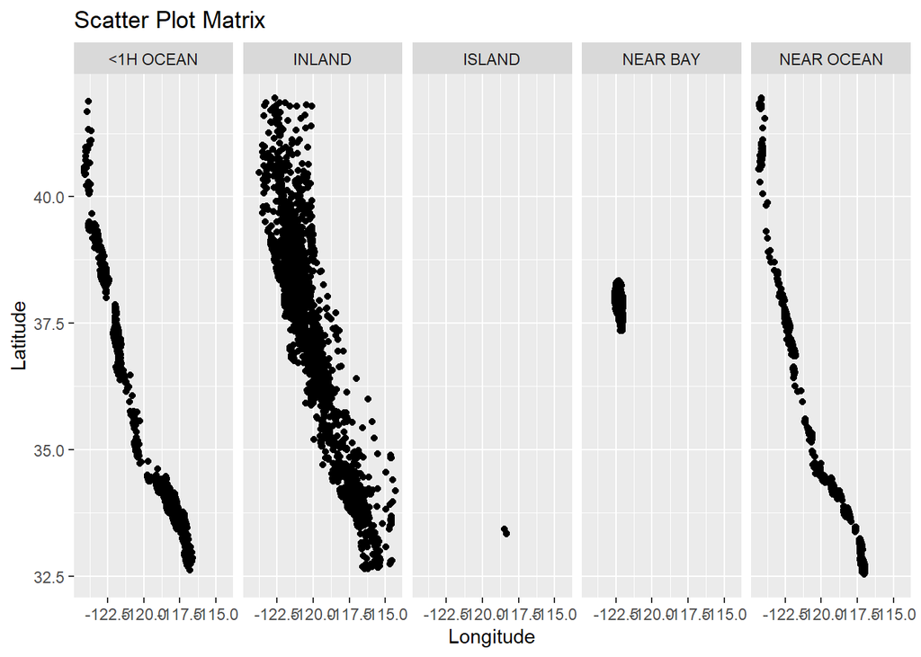

```r
library(ggplot2)

scatter_plot_matrix <- ggplot(housing, aes(x = longitude, y = latitude)) +
  geom_point() +
  facet_grid(. ~ proximity_to_ocean) +
  xlab("Longitude") +
  ylab("Latitude") +
  ggtitle("Scatter Plot Matrix")

print(scatter_plot_matrix)
```

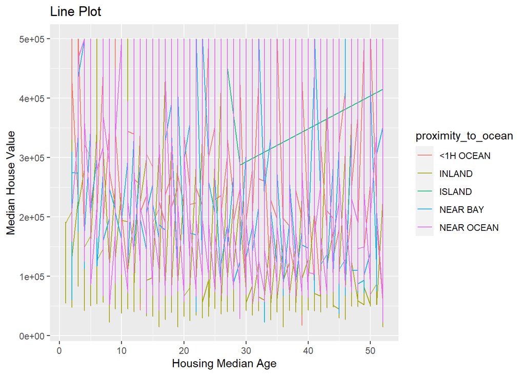

```r
line_plot <- ggplot(housing, aes(x = housing_median_age, y = median_house_value, color = proximity_to_ocean)) +
  geom_line() +
  xlab("Housing Median Age") +
  ylab("Median House Value") +
  ggtitle("Line Plot")

print(line_plot)
```

## Create a scatter plot with a trend line:

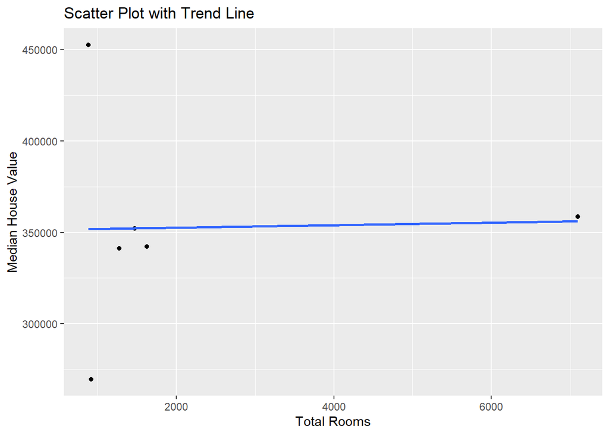

```r
library(ggplot2)
temp <- head(housing)
scatter_plot <- ggplot(temp, aes(x = total_rooms, y = median_house_value)) +
  geom_point() +
  geom_smooth(method = "lm", se = FALSE) +
  xlab("Total Rooms") +
  ylab("Median House Value") +
  ggtitle("Scatter Plot with Trend Line")

print(scatter_plot)
```

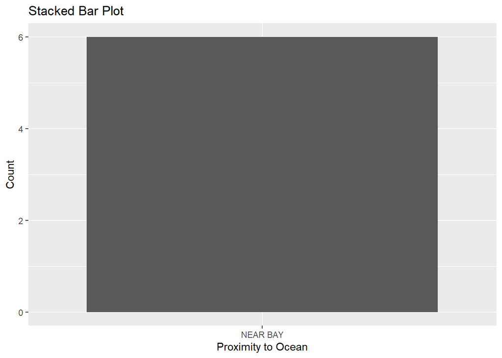

```r
stacked_bar_plot <- ggplot(temp, aes(x = proximity_to_ocean, fill = housing_median_age)) +
  geom_bar(position = "stack") +
  xlab("Proximity to Ocean") +
  ylab("Count") +
  ggtitle("Stacked Bar Plot")

print(stacked_bar_plot)
```

## Create a pie chart:

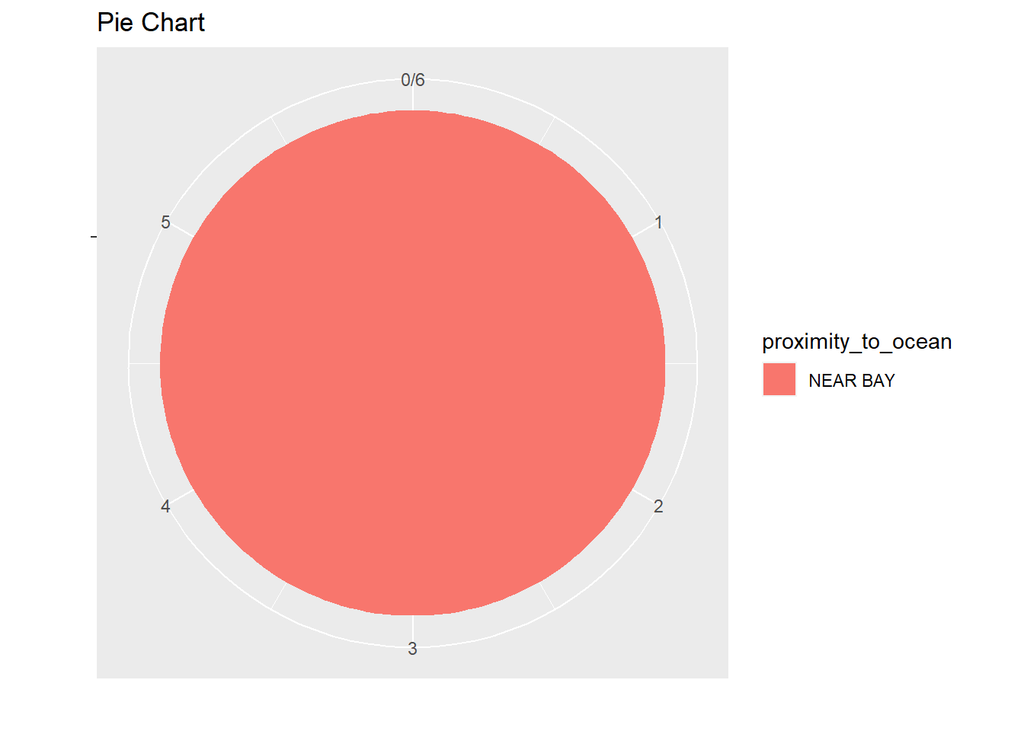

```r
pie_chart <- ggplot(temp, aes(x = "", fill = proximity_to_ocean)) +
  geom_bar(width = 1) +
  coord_polar("y", start = 0) +
  xlab("") +
  ylab("") +
  ggtitle("Pie Chart")

print(pie_chart)
```

## Create a scatter plot with jittered data points:

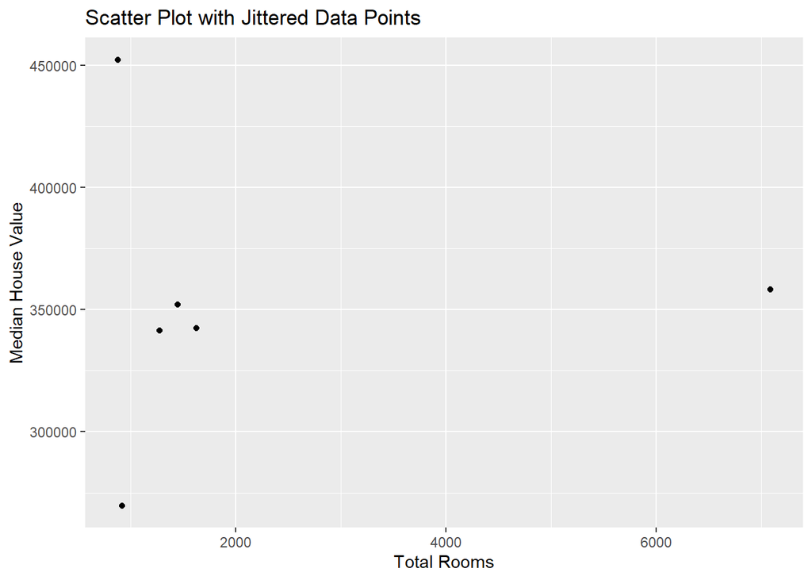

```r
scatter_plot <- ggplot(temp, aes(x = total_rooms, y = median_house_value)) +
  geom_jitter() +
  xlab("Total Rooms") +
  ylab("Median House Value") +
  ggtitle("Scatter Plot with Jittered Data Points")

print(scatter_plot)
```